# Do differences in SI make a difference in patient rates compared to risk factors?

2023-02-15

### loading the dataset

```r
setwd("C:/Users/A S Computer/Downloads")
# Loading
library("readxl")


# xlsx files
df <- read_excel("DATA_2.xlsx")
#structure of data
str(df)
```

```
## tibble [38 × 7] (S3: tbl_df/tbl/data.frame)
##  $ ...1               : chr [1:38] "DCC1" "DCC2" "DCC3" "DCC4" ...
##  $ Level              : num [1:38] 1 1 1 1 1 1 1 1 1 1 ...
##  $ SI                 : num [1:38] 2.9 3.5 3.2 3.2 2.5 2.7 3.8 3.5 2.6 6.2 ...
##  $ Evaluation         : chr [1:38] "High" "High" "High" "Median" ...
##  $ Risk  Factor Score : num [1:38] 10 10 10 9 8 9 10 7 7 7 ...
##  $ Incidence Rate     : num [1:38] 7.17 5.11 1.96 1.69 6.94 ...
##  $ Secondary incidence: num [1:38] 2 2.113 2.878 0.643 7.2 ...
```

```r
# omiting the NA values
df = na.omit(df)
```

### EDA

```r
#corelation plot
cor(df[,c(3,5,6,7)])
```

```
##                             SI Risk  Factor Score Incidence Rate
## SI                   1.0000000         -0.2021331     -0.2090071
## Risk  Factor Score  -0.2021331          1.0000000      0.2846465
## Incidence Rate      -0.2090071          0.2846465      1.0000000
## Secondary incidence -0.1265185          0.1224013      0.7851501
##                     Secondary incidence
## SI                           -0.1265185
## Risk  Factor Score            0.1224013
## Incidence Rate                0.7851501
## Secondary incidence           1.0000000
```

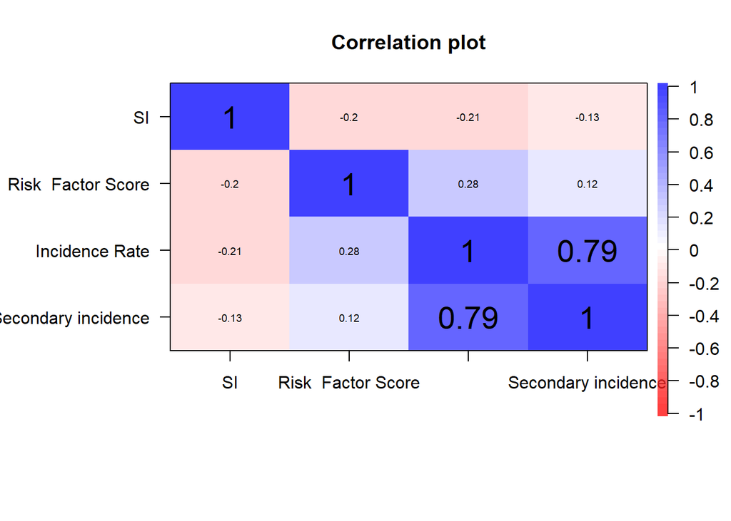

```r
library(psych)

corPlot(df[,c(3,5,6,7)], cex = 1.2)
```

We found out the correlation among the all the numerical variables which includes the SI, Risk factor score, Incidence rate and secondary incidence. The SI score has not good relationship with the Incidence rate and secondary incidence. The only two variables has the strong correlation which are Incidence rate and secondary incidence having the strong correlation of 0.79.

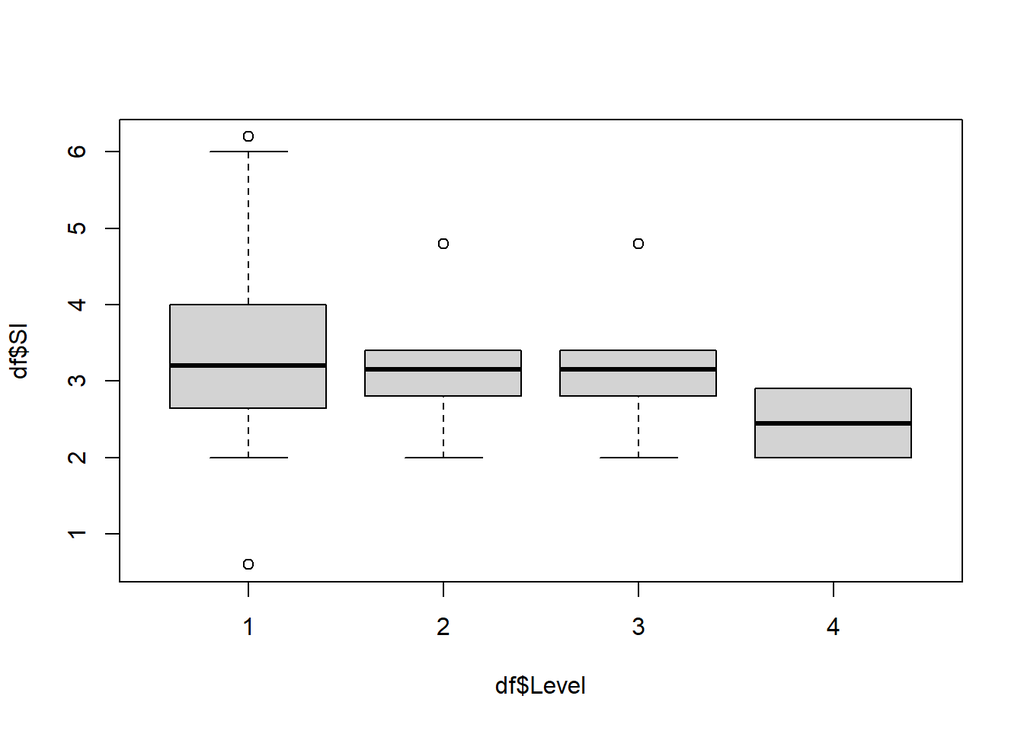

```r
boxplot(df$SI~df$Level)
```

For the level 1, 2, 3, and 4 the SI values mean remain the same but for the Level 4 the values for the SI are decreased

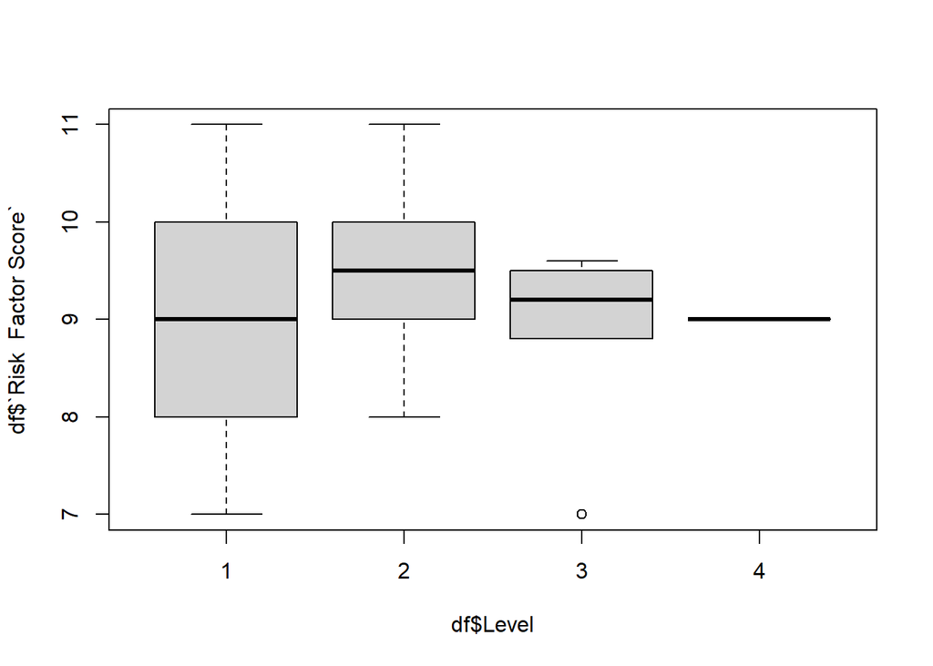

```r
boxplot(df$`Risk  Factor Score`~df$Level)
```

For the Level 2 patients the Risk factor mean score is higher as related to other patients.

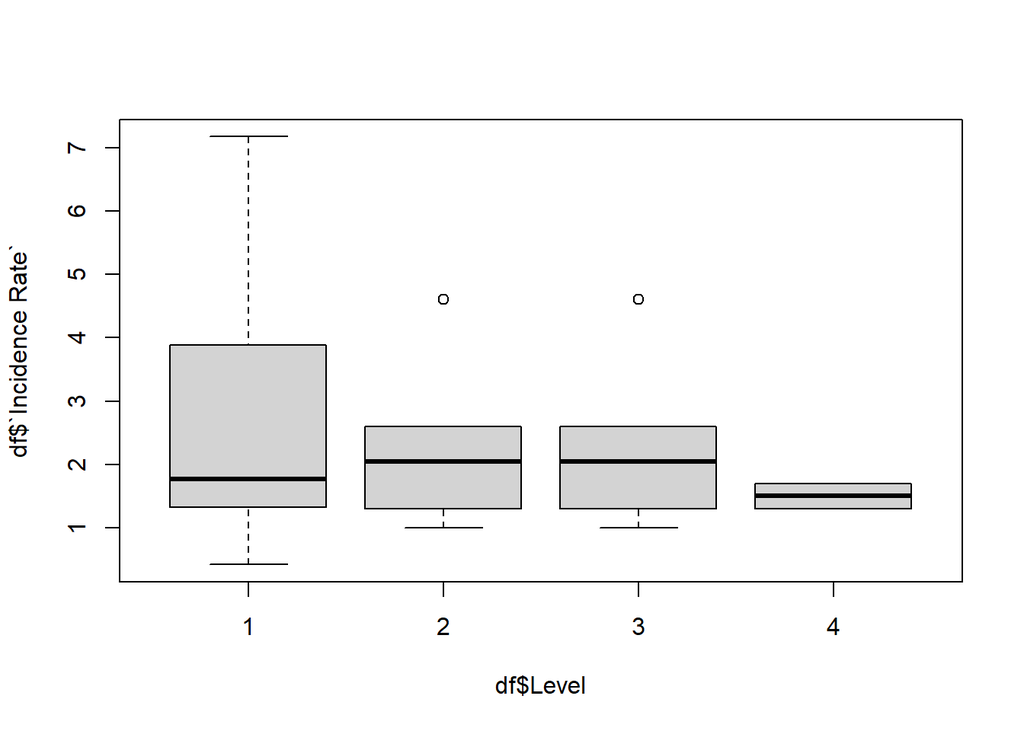

```r
boxplot(df$`Incidence Rate`~df$Level)
```

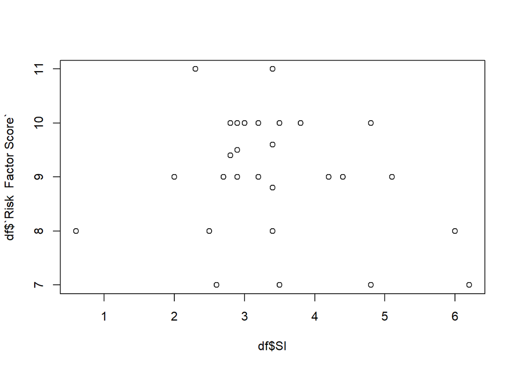

```r
plot(df$SI, df$`Risk  Factor Score`)
```

As such we have not seen any correlation among the SI and teh Risk factor analysis as shown in the plot above.